# Flexible Damage Functions

Year 2098 · T<sub>mean</sub> across these regions: 2.05°C

| Region | Raw | Flex | Residual |
| --- | --- | --- | --- |
| FJI.R13886963f95ae1bc | 0 | 0 | 0 |
| TUV.R06fb643237e8113e | 0 | 0 | 0 |
| USA.45.2797 | 0 | 0 | 0 |
| USA.48.2977 | 0 | 0 | 0 |
| USA.48.2981 | 0 | 0 | 0 |
| IND.35.580.2260 | 0.332 | -0.896 | -1.23 |
| IND.35.580.2259 | 0.108 | -1.11 | -1.22 |
| IND.35.580.2261 | 0.226 | -0.987 | -1.21 |
| IND.35.593.2295 | 0.0866 | -1.12 | -1.2 |
| IND.35.580.2258 | 0.208 | -0.94 | -1.15 |

**rcp85**

**SSP2**

**high**

**Correlation:** 0.9143 | **RMSE:** 0.216396 | **Sign agreement:** 96.3%

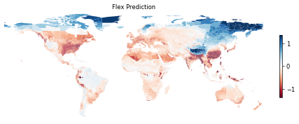

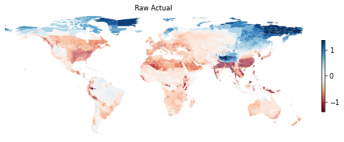

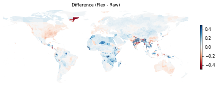

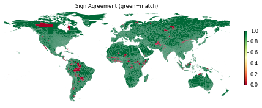

[interactive chart not shown]

Top 5 best predicted Top 5 worst predicted

Year 2098 · T<sub>mean</sub> across these regions: 4.51°C

| Region | Raw | Flex | Residual |
| --- | --- | --- | --- |
| FJI.R13886963f95ae1bc | 0 | 0 | 0 |
| TUV.R06fb643237e8113e | 0 | 0 | 0 |
| USA.45.2797 | 0 | 0 | 0 |
| USA.48.2977 | 0 | 0 | 0 |
| USA.48.2981 | 0 | 0 | 0 |
| BGD.1.1.1.8 | -2.53 | -0.96 | 1.57 |
| BGD.2.7.15.108 | -2.52 | -0.954 | 1.56 |
| BGD.2.5.12.91 | -2.78 | -1.25 | 1.53 |
| BGD.2.5.11.76 | -2.69 | -1.17 | 1.52 |
| BGD.2.7.15.109 | -2.68 | -1.17 | 1.51 |

**low**

**Correlation:** 0.9230 | **RMSE:** 0.195663 | **Sign agreement:** 96.4%

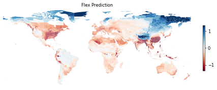

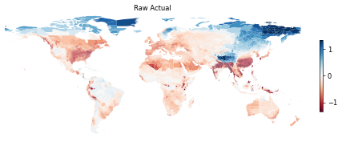

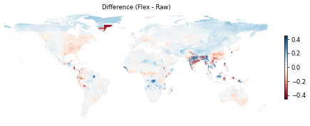

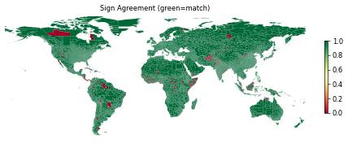

[interactive chart not shown]

Top 5 best predicted Top 5 worst predicted

Year 2098 · T<sub>mean</sub> across these regions: 4.51°C

| Region | Raw | Flex | Residual |
| --- | --- | --- | --- |
| FJI.R13886963f95ae1bc | 0 | 0 | 0 |
| TUV.R06fb643237e8113e | 0 | 0 | 0 |
| USA.45.2797 | 0 | 0 | 0 |
| USA.48.2977 | 0 | 0 | 0 |
| USA.48.2981 | 0 | 0 | 0 |
| MMR.12.47.220 | -1.9 | -0.404 | 1.5 |
| BGD.2.7.15.108 | -2.47 | -0.992 | 1.48 |
| BGD.2.5.12.91 | -2.75 | -1.3 | 1.45 |
| IND.4.43.230 | -0.764 | -2.21 | -1.45 |
| MMR.4.12.67 | -2.34 | -0.908 | 1.43 |

**SSP3**

**high**

**Correlation:** 0.9285 | **RMSE:** 0.197820 | **Sign agreement:** 96.8%

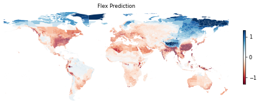

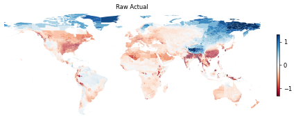

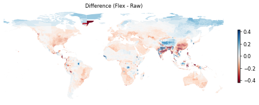

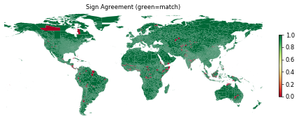

[interactive chart not shown]

Top 5 best predicted Top 5 worst predicted

Year 2098 · T<sub>mean</sub> across these regions: 4.51°C

| Region | Raw | Flex | Residual |
| --- | --- | --- | --- |
| FJI.R13886963f95ae1bc | 0 | 0 | 0 |
| TUV.R06fb643237e8113e | 0 | 0 | 0 |
| USA.45.2797 | 0 | 0 | 0 |
| USA.48.2977 | 0 | 0 | 0 |
| USA.48.2981 | 0 | 0 | 0 |
| IND.23.352.1497 | -1.26 | -3.14 | -1.88 |
| IND.22.342.1474 | -0.542 | -2.13 | -1.59 |
| IND.4.52.239 | -0.679 | -2.27 | -1.59 |
| IND.4.43.230 | -0.727 | -2.31 | -1.58 |
| IND.35.585.2273 | -1.05 | -2.57 | -1.52 |

**low**

**Correlation:** 0.9274 | **RMSE:** 0.205873 | **Sign agreement:** 94.6%

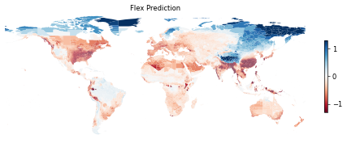

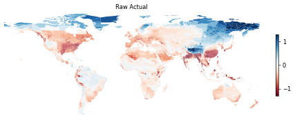

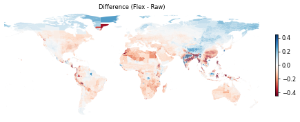

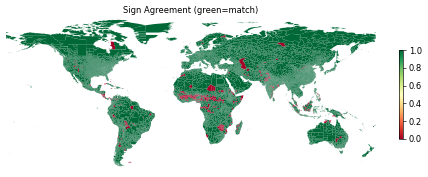

[interactive chart not shown]

Top 5 best predicted Top 5 worst predicted

Year 2098 · T<sub>mean</sub> across these regions: 4.51°C

| Region | Raw | Flex | Residual |
| --- | --- | --- | --- |
| FJI.R13886963f95ae1bc | 0 | 0 | 0 |
| TUV.R06fb643237e8113e | 0 | 0 | 0 |
| USA.45.2797 | 0 | 0 | 0 |
| USA.48.2977 | 0 | 0 | 0 |
| USA.48.2981 | 0 | 0 | 0 |
| IND.23.352.1497 | -1.29 | -3.12 | -1.82 |
| BGD.6.23.66.R965ed56cb8321b6e | -1.01 | -2.72 | -1.71 |
| BGD.6.23.66.R3bd21c027b2f71eb | -1.38 | -2.95 | -1.57 |
| MMR.10.36.171 | -1.16 | -2.72 | -1.56 |
| IND.22.342.1474 | -0.588 | -2.12 | -1.53 |

**SSP4**

**high**

**Correlation:** 0.9239 | **RMSE:** 0.193750 | **Sign agreement:** 96.0%

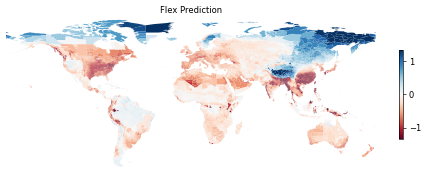

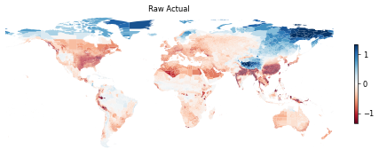

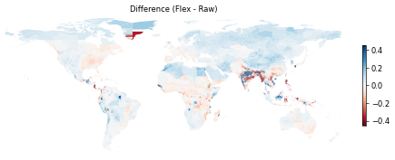

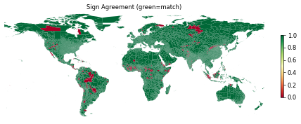

[interactive chart not shown]

Top 5 best predicted Top 5 worst predicted

Year 2098 · T<sub>mean</sub> across these regions: 4.51°C

| Region | Raw | Flex | Residual |
| --- | --- | --- | --- |
| FJI.R13886963f95ae1bc | 0 | 0 | 0 |
| TUV.R06fb643237e8113e | 0 | 0 | 0 |
| USA.45.2797 | 0 | 0 | 0 |
| USA.48.2977 | 0 | 0 | 0 |
| USA.48.2981 | 0 | 0 | 0 |
| MMR.10.36.171 | -1.19 | -2.83 | -1.64 |
| MMR.1.1.1 | -1.24 | -2.73 | -1.49 |
| MMR.1.2.11 | -1.14 | -2.59 | -1.45 |
| IND.20.287.1081 | -2.54 | -1.12 | 1.42 |
| MMR.1.1.5 | -1.17 | -2.6 | -1.42 |

**low**

**Correlation:** 0.9324 | **RMSE:** 0.196307 | **Sign agreement:** 96.2%

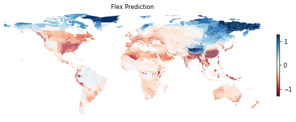

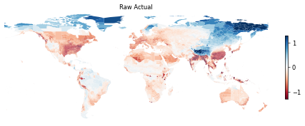

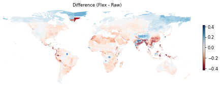

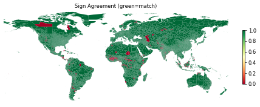

[interactive chart not shown]

Top 5 best predicted Top 5 worst predicted

Year 2098 · T<sub>mean</sub> across these regions: 4.51°C

| Region | Raw | Flex | Residual |
| --- | --- | --- | --- |
| FJI.R13886963f95ae1bc | 0 | 0 | 0 |
| TUV.R06fb643237e8113e | 0 | 0 | 0 |
| USA.45.2797 | 0 | 0 | 0 |
| USA.48.2977 | 0 | 0 | 0 |
| USA.48.2981 | 0 | 0 | 0 |
| IND.23.352.1497 | -1.12 | -3.1 | -1.99 |
| MMR.10.36.171 | -1.04 | -2.83 | -1.78 |
| IND.4.43.230 | -0.565 | -2.28 | -1.72 |
| IND.22.342.1474 | -0.444 | -2.11 | -1.66 |
| MMR.1.1.1 | -1.08 | -2.73 | -1.64 |

**Note · countries with no wheat combined data** (shown white on every map above; the GCP wheat combined pipeline does not run sims for non-producing countries): ATA, BVT, CL-, HMD, IOT, SGS, SP-.

## 10.1 Scenario Summary

Table 7: Fit statistics across all 12 scenarios

| RCP | SSP | Model | N | Corr | RMSE | Sign% |
| --- | --- | --- | --- | --- | --- | --- |
| rcp45 | SSP2 | high | 24,326 | 0.8476 | 0.133119 | 93.6% |
| rcp45 | SSP2 | low | 24,326 | 0.8638 | 0.121769 | 94.2% |
| rcp45 | SSP3 | high | 24,326 | 0.8619 | 0.123813 | 94.0% |
| rcp45 | SSP3 | low | 24,326 | 0.8663 | 0.119852 | 93.5% |
| rcp45 | SSP4 | high | 24,326 | 0.8517 | 0.127091 | 93.7% |
| rcp45 | SSP4 | low | 24,326 | 0.8452 | 0.128002 | 93.6% |
| rcp85 | SSP2 | high | 24,326 | 0.9143 | 0.216396 | 96.3% |
| rcp85 | SSP2 | low | 24,326 | 0.923 | 0.195663 | 96.4% |
| rcp85 | SSP3 | high | 24,326 | 0.9285 | 0.19782 | 96.8% |
| rcp85 | SSP3 | low | 24,326 | 0.9274 | 0.205873 | 94.6% |
| rcp85 | SSP4 | high | 24,326 | 0.9239 | 0.19375 | 96.0% |
| rcp85 | SSP4 | low | 24,326 | 0.9324 | 0.196307 | 96.2% |

# 11 Data Reference

## 11.1 File Locations

| Item | Path |
| --- | --- |
| Regional CSV | `/project/cil/gcp/flex_damage_funcs/parameters/agriculture__wheat_combined__regional_parameters.csv` |
| Global JSON | `/project/cil/gcp/flex_damage_funcs/parameters/agriculture__wheat_combined__global_results.json` |
| Metadata JSON | `/project/cil/gcp/flex_damage_funcs/parameters/agriculture__wheat_combined__metadata.json` |

## 11.2 Column Definitions

| Column | Description |
| --- | --- |
| `region` | Region identifier (hierarchical code, first 3 chars = country ISO3) |
| `gamma` | Income elasticity quantile value |
| `alpha` | Linear temperature coefficient |
| `beta` | Quadratic temperature coefficient |
| `sigma11` | Var(alpha) |
| `sigma12` | Cov(alpha, beta) |
| `sigma22` | Var(beta) |
| `rho` | Correlation with global residual process |
| `zeta` | Temperature-dependent heteroskedasticity |
| `eta` | Residual standard deviation |
| `rsqr1` | R-squared of polynomial fit |
| `rsqr2` | R-squared of error model |

*Report generated with FlexDamage v1.0.0*